# STA 141A Homework 3

Li Yuan

4/22/2022

# Problem 1: ggplot

## Question 1

Consider the following code. Using your own words, explain why the points are not green? (1 point)

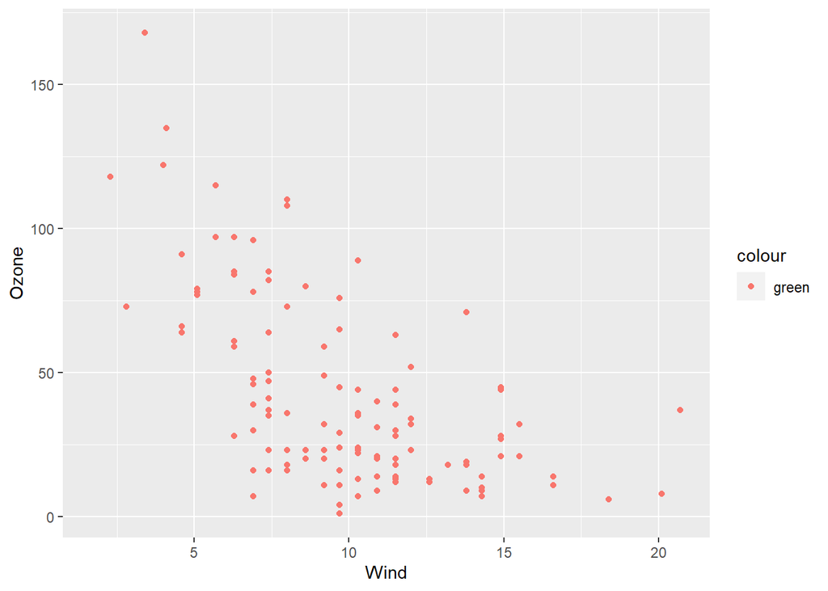

```r
require(ggplot2)
ggplot(data = airquality) +
  geom_point(mapping = aes(x = Wind, y = Ozone, color = "green"))
```

The points are not green because the function recognizes `color` as a variable equals to `"green"`, which has the same property as `x = Wind` and `y = Ozone`. If we really want to change the color to green, we need to add `color="green"` outside the `aes()` function. The correct code is shown as following:

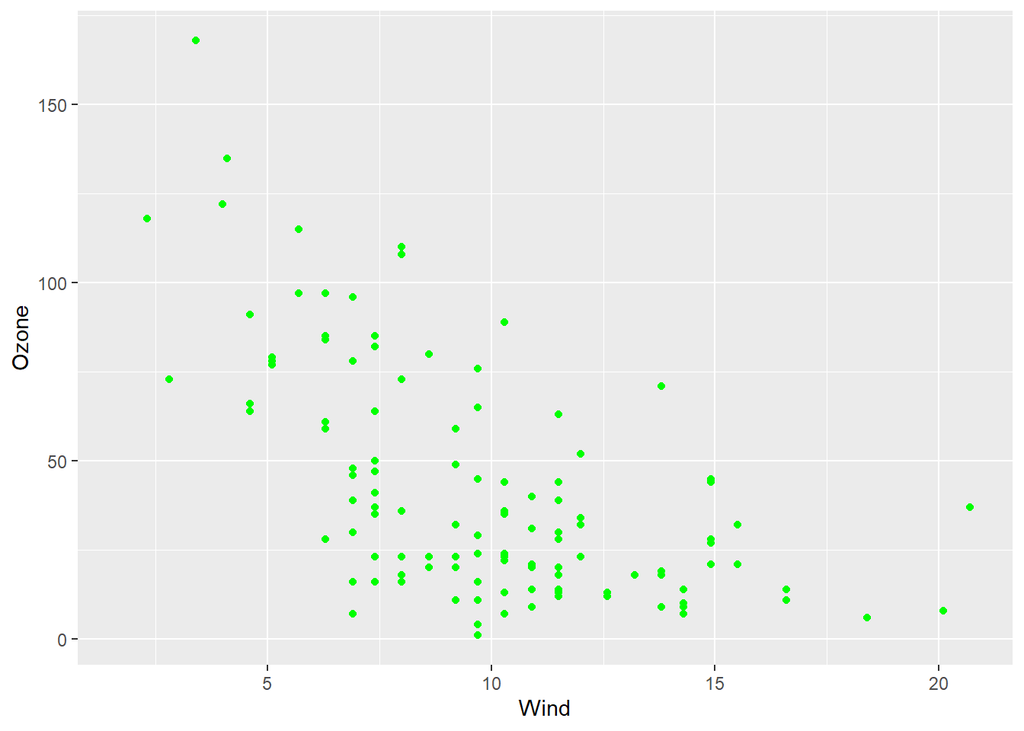

```r
ggplot(data = airquality) +
  geom_point(mapping = aes(x = Wind, y = Ozone), color = "green")
```

## Question 2

Map a continuous variable to color, size, and shape. In words, explain why these aesthetics behave differently for categorical vs. continuous variables. (1 point)

```r
head(airquality, 1)
```

```
##   Ozone Solar.R Wind Temp Month Day
## 1    41     190  7.4   67     5   1
```

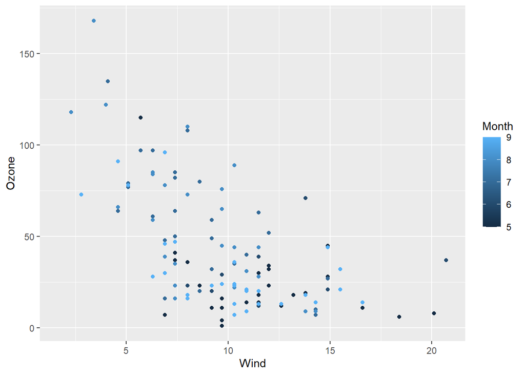

```r
ggplot(data = airquality) +
  geom_point(mapping = aes(x = Wind, y = Ozone,
                           color = Month))
```

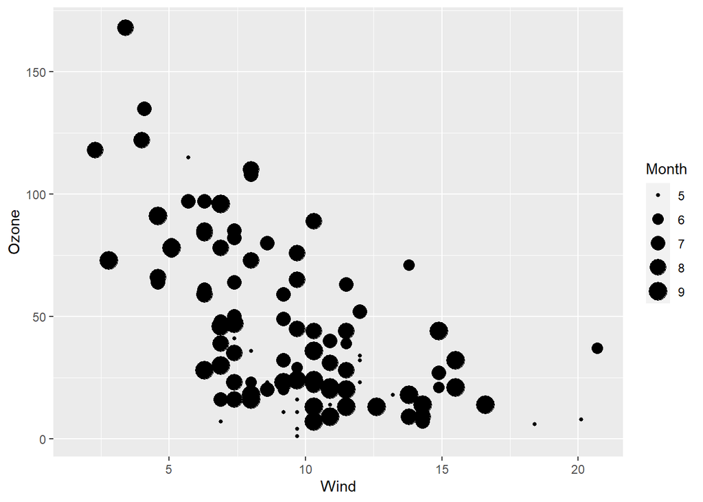

```r
ggplot(data = airquality) +
  geom_point(mapping = aes(x = Wind, y = Ozone,
                           size = Month))
```

```r
# This will show error, shape only takes categorical variable
ggplot(data = airquality) +
  geom_point(mapping = aes(x = Wind, y = Ozone,
                           shape = Month))
```

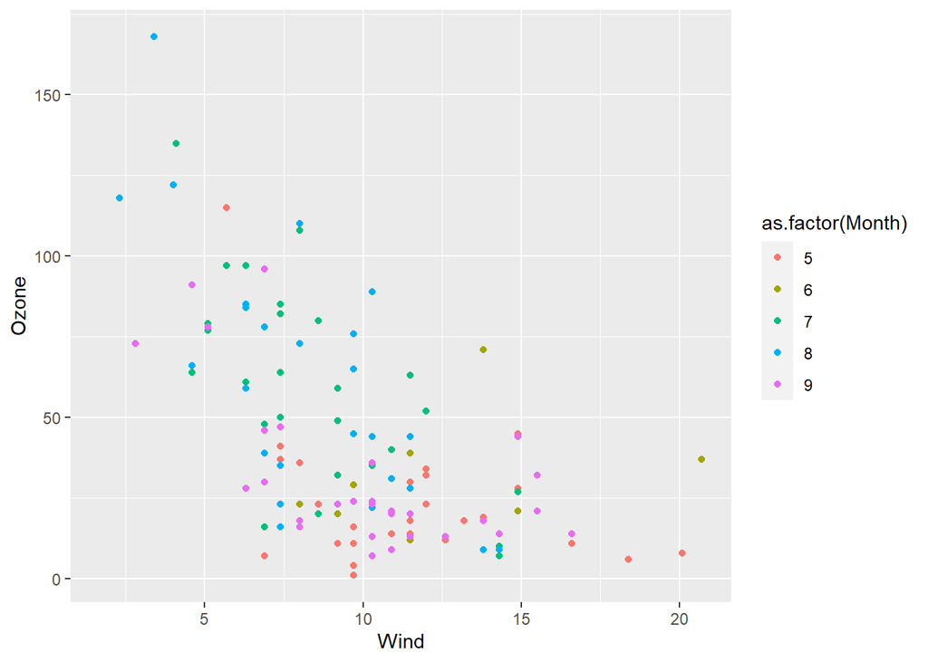

```r
ggplot(data = airquality) +
  geom_point(mapping = aes(x = Wind, y = Ozone,
                           color = as.factor(Month)))
```

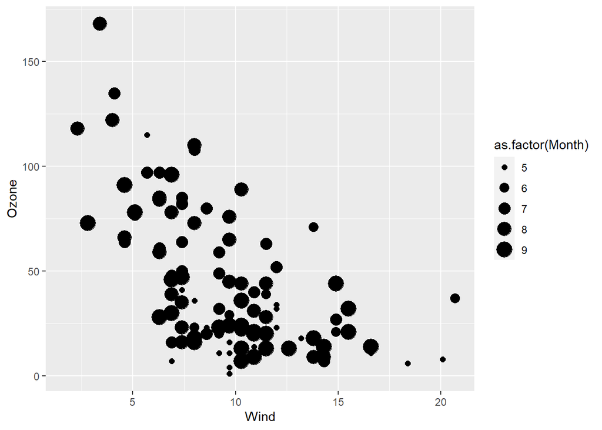

```r
ggplot(data = airquality) +
  geom_point(mapping = aes(x = Wind, y = Ozone,
                           size = as.factor(Month)))
```

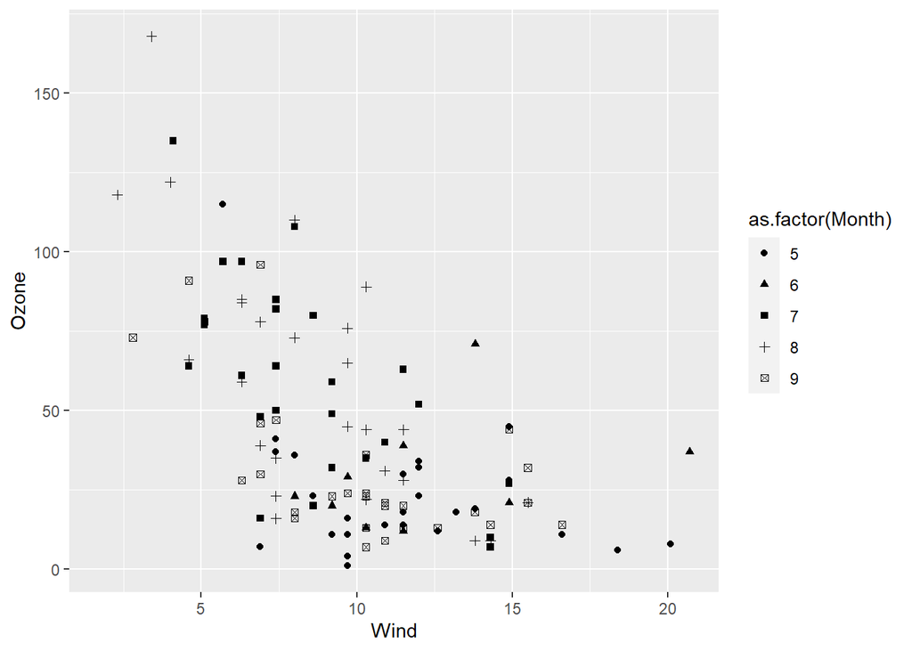

```r
ggplot(data = airquality) +
  geom_point(mapping = aes(x = Wind, y = Ozone,
                           shape = as.factor(Month)))
```

As we can see from above, when mapping continuous variables, there will have continuous scales on the right side. However, when mapping categorical variables, the right side may not show scales. Instead, it will show the elements in each categorical variable. For example, when mapping Month as a continuous variable, it only shows a color bar with numbers, but when mapping Month as a categorical variable it shows dots with different colors and numbers. In addition, we can only map a categorical variable to shape.

The difference exists because continuous variables are mainly numbers, which we can do a lot of calculation on it, but categorical variables are mainly characters, we can only few analysis on it.

## Question 3

In words, explain what happens if you map the same variable to multiple aesthetics? (1 point)

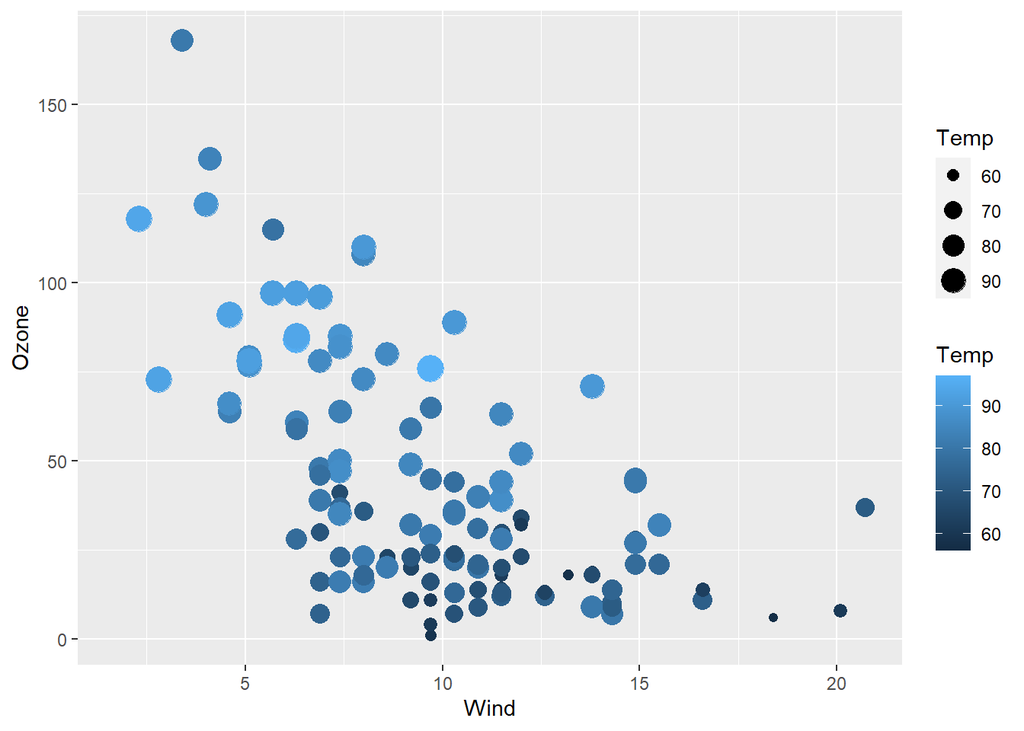

```r
ggplot(data = airquality) +
  geom_point(mapping = aes(x = Wind, y = Ozone,
                           color = Temp,
                           size = Temp))
```

Take the plot above as an example, the two aesthetics `color` and `size` are assigned to `Temp`. We can see that both of these aesthetics are applied to the variable. When `Temp` is 60, the points are small and the color is very dark, and when `Temp` is 90 the points are big and the color is very light.

## Question 4

What happens if you map an aesthetic to something other than a variable name, like aes(colour = Temp < 70)? Note, you’ll also need to specify x and y (2 points)

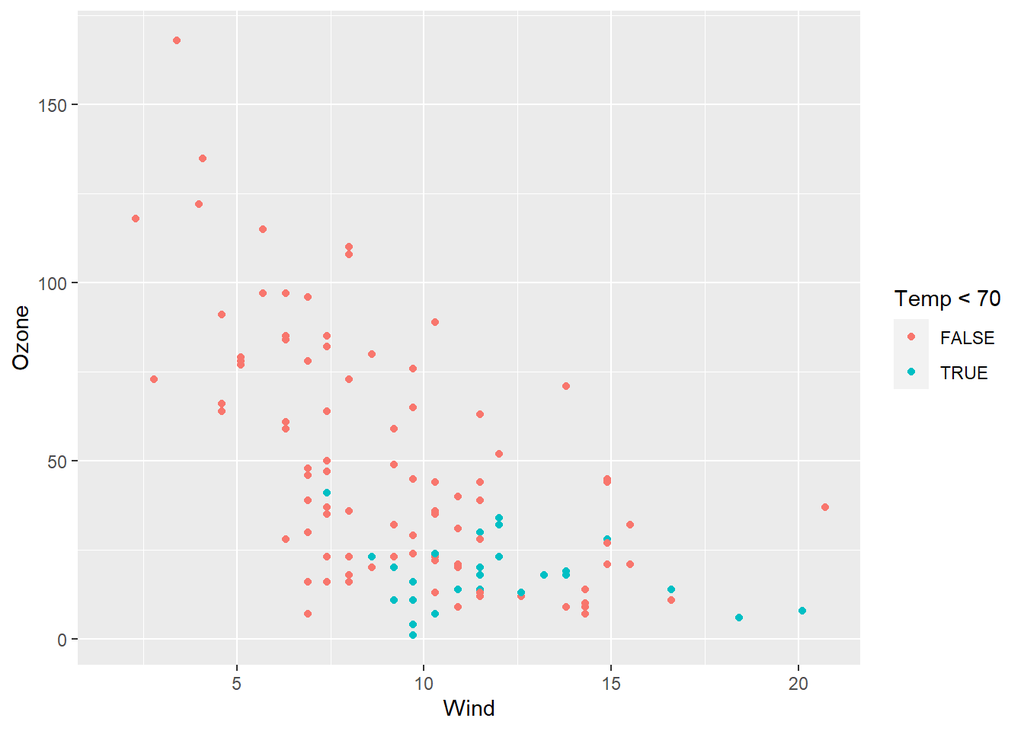

```r
ggplot(data = airquality) +
  geom_point(mapping = aes(x = Wind, y = Ozone, colour = Temp < 70))
```

# Problem 2: Simulation study

Suppose that $X_1, ...,X_n$ are independent and identically distributed (iid) binomial random variables such that
$$P(X_i=x|k,p)=\binom{k}{x}p^x(1-p)^{k-x},~x=0,1,...,k$$
for all $i=1,...,n$. Assume that both $k$ and $p$ are unknown and use the method of moments to obtain point estimators of both parameters. This somewhat unusual application of the binomial model has been used to estimate crime rates for crimes that are known to have many unreported occurrences. For such a crime, both the true reporting rate, $p$, and the total number of occurrences, $k$, are unknown. Equating the first two sample moments to those of the population yields the system of equations
$$\bar{X}=kp~~and~~\frac{1}{n}\Sigma_{i=1}^{n}X_i^2=kp(1-p)+k^2p^2,$$
where $\bar{X}$ is the sample mean. Sloving for $k$ and $p$ leads to
$$\hat{k}=\frac{\bar{X}^2}{\bar{X}-(1/n)\Sigma_{i=1}^{n}(X_i-\bar{X})^2}~~ and ~~\hat{p}=\frac{\bar{X}}{\hat{k}}$$
It is difficult to analyze the performance of $\hat{k}$ and $\hat{p}$ analytically so you are asked to perform a simulation study using `R`. The idea is to generate random samples and investigate the performance of $\hat{k}$ and $\hat{p}$ using random samples.

## Question 1

Generate a single simple random sample of length `n <- 50` from the binomial distribution with the parameters `k <- 10`, `p <- 0.4` (1 point).

```r
k = 10
p = 0.4
n = 50
sample = rbinom(n,k,p)
sample
```

```
##  [1] 5 4 3 4 3 3 4 2 1 5 3 4 7 5 5 2 2 5 5 5 1 5 6 4 3 5 7 6 5 4 1 1 5 3 3 3 5 2
## [39] 2 3 5 4 4 5 2 3 1 4 6 5
```

## Question 2

Write a function that takes a sample as its input and returns a vector containing the estimates of k and p given above (3 points).

```r
estimators = function(x){
  x_bar = mean(x)
  sum_square = 1/length(x) * sum(x^2)
  k_hat = x_bar^2 / (x_bar - (sum_square - x_bar^2))
  p_hat = x_bar / k_hat
  result = c(k_hat, p_hat)
  names(result) = c("k_hat", "p_hat")
  result
}
estimators(sample)
```

```
##      k_hat      p_hat
## 10.6176471  0.3578947
```

## Question 3

Generate `N <- 1000` samples of size `n <- 50` (as in the first question) and calculate `N <- 1000` estimates of $k$ and `N <- 1000` estimates of $p$ (4 points if no loops are used in the code, 2 points if any loop (for, while, repeat, etc.) is used in the code ).

```r
N <- 1000
simulation = as.list(as.data.frame(matrix(rbinom(N * n, k, p), nrow = n)))
result = lapply(simulation, estimators)
df50 = data.frame(matrix(unlist(result), nrow=length(result), byrow=TRUE))
names(df50) = c("k_hat", "p_hat")
head(df50)
```

```
##       k_hat     p_hat
## 1  9.790687 0.4146798
## 2 12.139169 0.3426923
## 3  7.920212 0.5075622
## 4  8.395349 0.4526316
## 5  8.594129 0.4677612
## 6 21.498783 0.1748936
```

## Question 4

Repeat Question 3 when `n <- 100` and when `n <- 250` (2 points).

```r
# n = 100
n <- 100
simulation = as.list(as.data.frame(matrix(rbinom(N * n, k, p), nrow = n)))
result = lapply(simulation, estimators)
df100 = data.frame(matrix(unlist(result), nrow=length(result), byrow=TRUE))
names(df100) = c("k_hat", "p_hat")
head(df100)
```

```
##       k_hat     p_hat
## 1 17.106268 0.2373399
## 2 11.199830 0.3401837
## 3 15.025349 0.2682134
## 4  8.989305 0.4560976
## 5 10.862942 0.3746683
## 6 10.423064 0.3712920
```

```r
# n = 250
n <- 250
simulation = as.list(as.data.frame(matrix(rbinom(N * n, k, p), nrow = n)))
result = lapply(simulation, estimators)
df250 = data.frame(matrix(unlist(result), nrow=length(result), byrow=TRUE))
names(df250) = c("k_hat", "p_hat")
head(df250)
```

```
##       k_hat     p_hat
## 1  8.627297 0.4599355
## 2  9.375498 0.4283506
## 3 11.043058 0.3556986
## 4  9.764081 0.4059778
## 5 12.211934 0.3321341
## 6 10.012959 0.3958870
```

## Question 5

Estimate the bias and the mean squared error (MSE) of $\hat{k}$ and the bias and the MSE of $\hat{p}$ for each sample size (`n <- 50`, `n <- 100` and `n <- 250`). Do the estimators seem to overestimate or underestimate the parameters? How do the bias and the MSE change when the sample size increases? (3 points).

```r
# MSE for n = 50 and k hat
mse_50_k = sum((df50$k_hat - mean(df50$k_hat))^2)/N
# MSE for n = 100 and k hat
mse_100_k = sum((df100$k_hat - mean(df100$k_hat))^2)/N
# MSE for n = 250 and k hat
mse_250_k = sum((df250$k_hat - mean(df250$k_hat))^2)/N

# MSE for n = 50 and p hat
mse_50_p = sum((df50$p_hat - mean(df50$p_hat))^2)/N
# MSE for n = 100 and p hat
mse_100_p = sum((df100$p_hat - mean(df100$p_hat))^2)/N
# MSE for n = 250 and p hat
mse_250_p = sum((df250$p_hat - mean(df250$p_hat))^2)/N

# bias for n = 50 and k hat
bias_50_k = mean(df50$k_hat) - k
# bias for n = 100 and k hat
bias_100_k = mean(df100$k_hat) - k
# bias for n = 250 and k hat
bias_250_k = mean(df250$k_hat) - k

# bias for n = 50 and p hat
bias_50_p = mean(df50$p_hat) - p
# bias for n = 100 and p hat
bias_100_p = mean(df100$p_hat) - p
# bias for n = 250 and p hat
bias_250_p = mean(df250$p_hat) - p

# Table for MSE's
mse_matrix = matrix(c(mse_50_k, mse_100_k, mse_250_k,
                      mse_50_p, mse_100_p, mse_250_p), byrow = TRUE, nrow = 2)
colnames(mse_matrix) = c("n = 50", "n = 100", "n = 250")
rownames(mse_matrix) = c("k hat", "p hat")
kable(mse_matrix, caption = "Table for MSE's")
```

Table for MSE’s

|  | n = 50 | n = 100 | n = 250 |
| --- | --- | --- | --- |
| k hat | 49.138800 | 5.8038205 | 2.0026006 |
| p hat | 0.013264 | 0.0069009 | 0.0026724 |

```r
# Table for biases
bias_matrix = matrix(c(bias_50_k, bias_100_k, bias_250_k,
                       bias_50_p, bias_100_p, bias_250_p), byrow = TRUE, nrow = 2)
colnames(bias_matrix) = c("n = 50", "n = 100", "n = 250")
rownames(bias_matrix) = c("k hat", "p hat")
kable(bias_matrix, caption = "Table for biases")
```

Table for biases

|  | n = 50 | n = 100 | n = 250 |
| --- | --- | --- | --- |
| k hat | 0.9790828 | 0.2330766 | 0.1640572 |
| p hat | 0.0115553 | 0.0092799 | 0.0005304 |

Since the biases are positive, our estimators $\hat{k}$ and $\hat{p}$ overestimate the parameters $k$ and $p$. Moreover, as the sample size $n$ increases, our MSE and bias of estimators $\hat{k}$ and $\hat{p}$ decreases.

## Question 6

1. Make a single plot using `ggplot2` that contains three box plots of the estimates of the parameter `k` when `n <- 50`, `n <- 100`, `n <- 250` (the first from the left box plot has to describe the estimates when `n <- 50`, the second from the left box plot has to describe the estimates when `n <- 100` and the third from the left box plot has to describe the estimates `n <- 250`). Include the true value of the parameter as a horizontal line (`geom_hline()` and use the argument `color`) and label the plot appropriately (4 points).

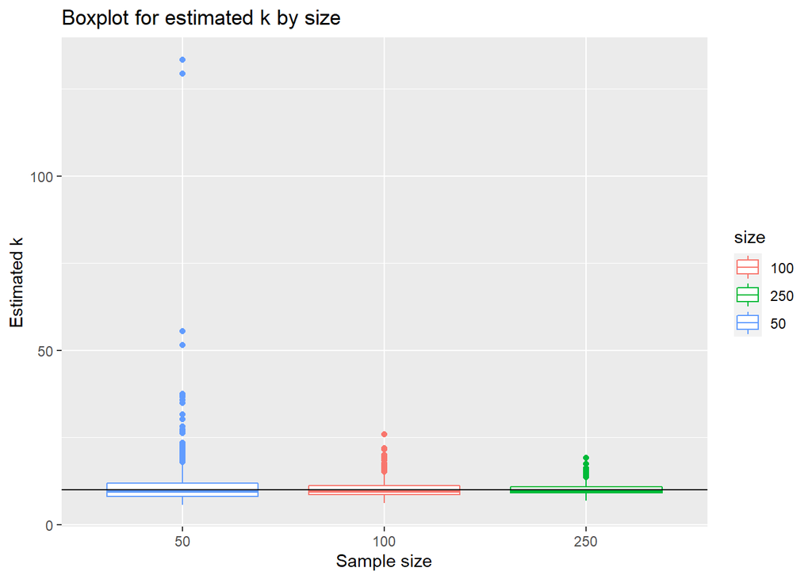

```r
size = rep(c('50', '100', '250'), each = 1000)
q6df = rbind(df50, df100, df250)
q6df = data.frame(size, q6df)
ggplot(data = q6df, mapping = aes(x = reorder(size, -k_hat), y = k_hat, col = size)) +
  geom_boxplot() +
  geom_hline(aes(yintercept = 10)) +
  ggtitle("Boxplot for estimated k by size") +
  labs(y = "Estimated k", x = "Sample size")
```

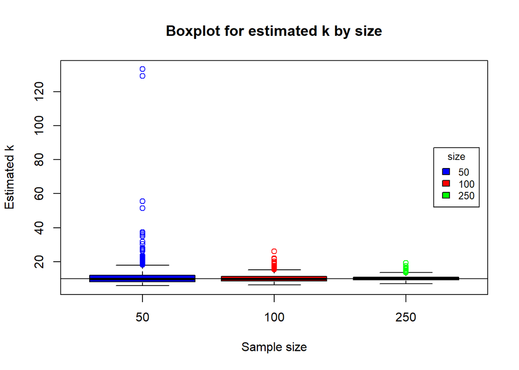

```r
# Extra credit - using basic R function
q6df$size = factor(q6df$size , levels=c('50', '100', '250'))
boxplot(k_hat ~ size, q6df,
        xlab = "Sample size", ylab = "Estimated k",
        main = "Boxplot for estimated k by size",
        col = c("blue", "red", "green"),
        outcol = c("blue", "red", "green"))
legend("right", inset=.02, title="size",
   c("50","100","250"), fill=c("blue", "red", "green"), horiz=FALSE, cex=0.8)
abline(h=10)
```

2. $\hat{k}$ can obtain values that are far away from the true value of the parameter when the sample size is small and the box plots might not be particularly informative in such a situation. Remove the estimates from the plot that are outside of the interval $[0,50]$ so that the box plots are more informative (4 points).

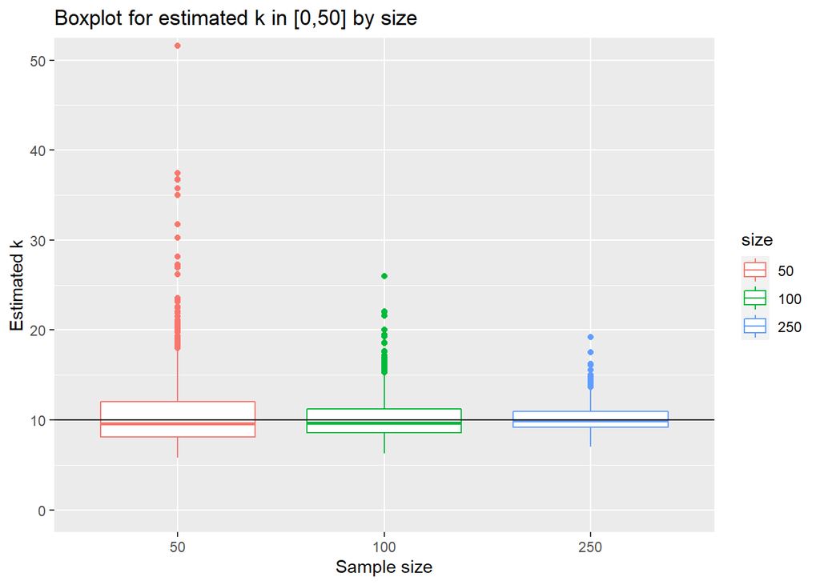

```r
ggplot(data = q6df, mapping = aes(x = reorder(size, -k_hat), y = k_hat, col = size)) +
  geom_boxplot() +
  geom_hline(aes(yintercept = 10)) +
  ggtitle("Boxplot for estimated k in [0,50] by size") +
  labs(y = "Estimated k", x = "Sample size") +
  coord_cartesian(ylim = c(0, 50))
```

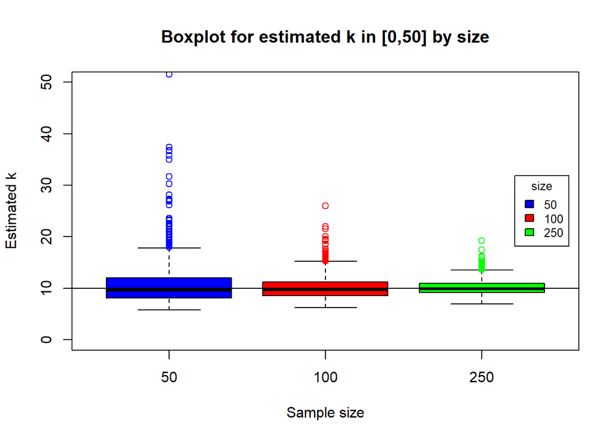

```r
boxplot(k_hat ~ size, q6df,
        xlab = "Sample size", ylab = "Estimated k",
        main = "Boxplot for estimated k in [0,50] by size",
        col = c("blue", "red", "green"), ylim = c(0, 50),
        outcol = c("blue", "red", "green"))
legend("right", inset=.02, title="size",
   c("50","100","250"), fill=c("blue", "red", "green"), horiz=FALSE, cex=0.8)
abline(h=10)
```

3. Make the same plot with three box plots for the estimates of the parameter `p` (b part does not apply here) (2 points).

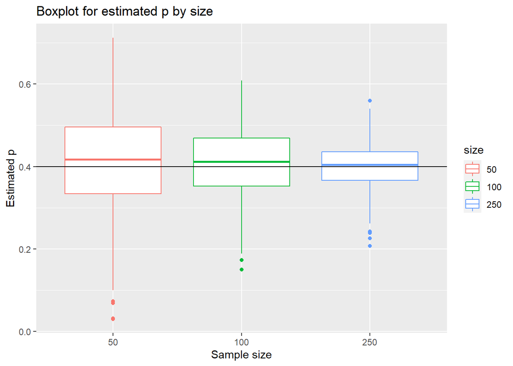

```r
ggplot(data = q6df, mapping = aes(x = reorder(size, -p_hat), y = p_hat, col = size)) +
  geom_boxplot() +
  geom_hline(aes(yintercept = 0.4)) +
  ggtitle("Boxplot for estimated p by size") +
  labs(y = "Estimated p", x = "Sample size")
```

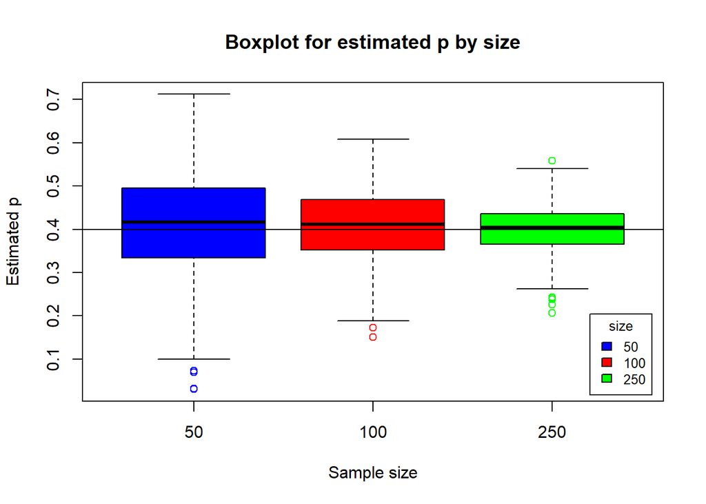

```r
#Extra credit - using base R function
boxplot(p_hat ~ size, q6df,
        xlab = "Sample size", ylab = "Estimated p",
        main = "Boxplot for estimated p by size",
        col = c("blue", "red", "green"),
        outcol = c("blue", "red", "green"))
legend("bottomright", inset=.02, title="size",
   c("50","100","250"), fill=c("blue", "red", "green"), horiz=FALSE, cex=0.8)
abline(h=0.4)
```

4. Describe how both of these plots change when the sample size increases (2 points).

From the plots above, we can see that when the sample size increases, the estimated values $\hat{k}$ and $\hat{p}$ are getting closer to their true values, which are $k=10$ and $p=0.4$.

# Appendix: R Script

```r
knitr::opts_chunk$set(echo = TRUE)
rm(list=ls())
library(knitr)
require(ggplot2)
ggplot(data = airquality) +
  geom_point(mapping = aes(x = Wind, y = Ozone, color = "green"))
ggplot(data = airquality) +
  geom_point(mapping = aes(x = Wind, y = Ozone), color = "green")
head(airquality, 1)
ggplot(data = airquality) +
  geom_point(mapping = aes(x = Wind, y = Ozone,
                           color = Month))
ggplot(data = airquality) +
  geom_point(mapping = aes(x = Wind, y = Ozone,
                           size = Month))
# This will show error, shape only takes categorical variable
ggplot(data = airquality) +
  geom_point(mapping = aes(x = Wind, y = Ozone,
                           shape = Month))
ggplot(data = airquality) +
  geom_point(mapping = aes(x = Wind, y = Ozone,
                           color = as.factor(Month)))
ggplot(data = airquality) +
  geom_point(mapping = aes(x = Wind, y = Ozone,
                           size = as.factor(Month)))
ggplot(data = airquality) +
  geom_point(mapping = aes(x = Wind, y = Ozone,
                           shape = as.factor(Month)))
ggplot(data = airquality) +
  geom_point(mapping = aes(x = Wind, y = Ozone,
                           color = Temp,
                           size = Temp))
ggplot(data = airquality) +
  geom_point(mapping = aes(x = Wind, y = Ozone, colour = Temp < 70))
k = 10
p = 0.4
n = 50
sample = rbinom(n,k,p)
sample
estimators = function(x){
  x_bar = mean(x)
  sum_square = 1/length(x) * sum(x^2)
  k_hat = x_bar^2 / (x_bar - (sum_square - x_bar^2))
  p_hat = x_bar / k_hat
  result = c(k_hat, p_hat)
  names(result) = c("k_hat", "p_hat")
  result
}
estimators(sample)
N <- 1000
simulation = as.list(as.data.frame(matrix(rbinom(N * n, k, p), nrow = n)))
result = lapply(simulation, estimators)
df50 = data.frame(matrix(unlist(result), nrow=length(result), byrow=TRUE))
names(df50) = c("k_hat", "p_hat")
head(df50)
# n = 100
n <- 100
simulation = as.list(as.data.frame(matrix(rbinom(N * n, k, p), nrow = n)))
result = lapply(simulation, estimators)
df100 = data.frame(matrix(unlist(result), nrow=length(result), byrow=TRUE))
names(df100) = c("k_hat", "p_hat")
head(df100)
# n = 250
n <- 250
simulation = as.list(as.data.frame(matrix(rbinom(N * n, k, p), nrow = n)))
result = lapply(simulation, estimators)
df250 = data.frame(matrix(unlist(result), nrow=length(result), byrow=TRUE))
names(df250) = c("k_hat", "p_hat")
head(df250)
# MSE for n = 50 and k hat
mse_50_k = sum((df50$k_hat - mean(df50$k_hat))^2)/N
# MSE for n = 100 and k hat
mse_100_k = sum((df100$k_hat - mean(df100$k_hat))^2)/N
# MSE for n = 250 and k hat
mse_250_k = sum((df250$k_hat - mean(df250$k_hat))^2)/N

# MSE for n = 50 and p hat
mse_50_p = sum((df50$p_hat - mean(df50$p_hat))^2)/N
# MSE for n = 100 and p hat
mse_100_p = sum((df100$p_hat - mean(df100$p_hat))^2)/N
# MSE for n = 250 and p hat
mse_250_p = sum((df250$p_hat - mean(df250$p_hat))^2)/N

# bias for n = 50 and k hat
bias_50_k = mean(df50$k_hat) - k
# bias for n = 100 and k hat
bias_100_k = mean(df100$k_hat) - k
# bias for n = 250 and k hat
bias_250_k = mean(df250$k_hat) - k

# bias for n = 50 and p hat
bias_50_p = mean(df50$p_hat) - p
# bias for n = 100 and p hat
bias_100_p = mean(df100$p_hat) - p
# bias for n = 250 and p hat
bias_250_p = mean(df250$p_hat) - p

# Table for MSE's
mse_matrix = matrix(c(mse_50_k, mse_100_k, mse_250_k,
                      mse_50_p, mse_100_p, mse_250_p), byrow = TRUE, nrow = 2)
colnames(mse_matrix) = c("n = 50", "n = 100", "n = 250")
rownames(mse_matrix) = c("k hat", "p hat")
kable(mse_matrix, caption = "Table for MSE's")

# Table for biases
bias_matrix = matrix(c(bias_50_k, bias_100_k, bias_250_k,
                       bias_50_p, bias_100_p, bias_250_p), byrow = TRUE, nrow = 2)
colnames(bias_matrix) = c("n = 50", "n = 100", "n = 250")
rownames(bias_matrix) = c("k hat", "p hat")
kable(bias_matrix, caption = "Table for biases")
size = rep(c('50', '100', '250'), each = 1000)
q6df = rbind(df50, df100, df250)
q6df = data.frame(size, q6df)
ggplot(data = q6df, mapping = aes(x = reorder(size, -k_hat), y = k_hat, col = size)) +
  geom_boxplot() +
  geom_hline(aes(yintercept = 10)) +
  ggtitle("Boxplot for estimated k by size") +
  labs(y = "Estimated k", x = "Sample size")
# Extra credit - using basic R function
q6df$size = factor(q6df$size , levels=c('50', '100', '250'))
boxplot(k_hat ~ size, q6df,
        xlab = "Sample size", ylab = "Estimated k",
        main = "Boxplot for estimated k by size",
        col = c("blue", "red", "green"),
        outcol = c("blue", "red", "green"))
legend("right", inset=.02, title="size",
   c("50","100","250"), fill=c("blue", "red", "green"), horiz=FALSE, cex=0.8)
abline(h=10)
ggplot(data = q6df, mapping = aes(x = reorder(size, -k_hat), y = k_hat, col = size)) +
  geom_boxplot() +
  geom_hline(aes(yintercept = 10)) +
  ggtitle("Boxplot for estimated k in [0,50] by size") +
  labs(y = "Estimated k", x = "Sample size") +
  coord_cartesian(ylim = c(0, 50))
boxplot(k_hat ~ size, q6df,
        xlab = "Sample size", ylab = "Estimated k",
        main = "Boxplot for estimated k in [0,50] by size",
        col = c("blue", "red", "green"), ylim = c(0, 50),
        outcol = c("blue", "red", "green"))
legend("right", inset=.02, title="size",
   c("50","100","250"), fill=c("blue", "red", "green"), horiz=FALSE, cex=0.8)
abline(h=10)
ggplot(data = q6df, mapping = aes(x = reorder(size, -p_hat), y = p_hat, col = size)) +
  geom_boxplot() +
  geom_hline(aes(yintercept = 0.4)) +
  ggtitle("Boxplot for estimated p by size") +
  labs(y = "Estimated p", x = "Sample size")
#Extra credit - using base R function
boxplot(p_hat ~ size, q6df,
        xlab = "Sample size", ylab = "Estimated p",
        main = "Boxplot for estimated p by size",
        col = c("blue", "red", "green"),
        outcol = c("blue", "red", "green"))
legend("bottomright", inset=.02, title="size",
   c("50","100","250"), fill=c("blue", "red", "green"), horiz=FALSE, cex=0.8)
abline(h=0.4)
```